# IE 451 Fall 2023-2024 Homework 6

Author

Mustafa Mert Türkmen

# 1

```r
d <- read_csv("pollution.csv")
```

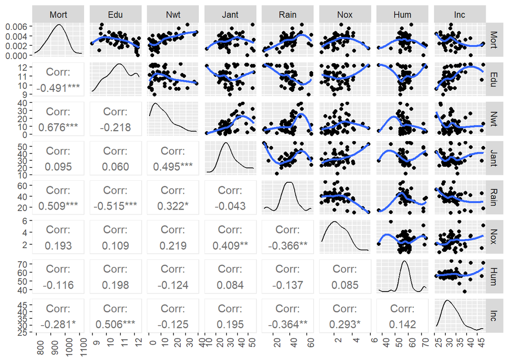

```r
my_fn <- function(data, mapping, method="loess", ...){
      p <- ggplot(data = data, mapping = mapping) +
      geom_point() +
      geom_smooth(formula = y ~ x,method=method,se=F, ...)
      p
}

d[-1] %>%
  relocate(Mort)%>%
  ggpairs(progress = FALSE,
          upper = list(continuous = my_fn),
          lower = list(continuous = "cor"))+theme(axis.text.x = element_text(angle = 90))
```

- With looking there I think there are interpretable relations between predictors and our response variable.
- Mort has negative relation with edu, hum and inc with looking their correlation values.
- Positive correlation with the rest, some of the relations looking like significant.
- Let’s look at their plots one by one to make comment about their relation with our response variable mortality.

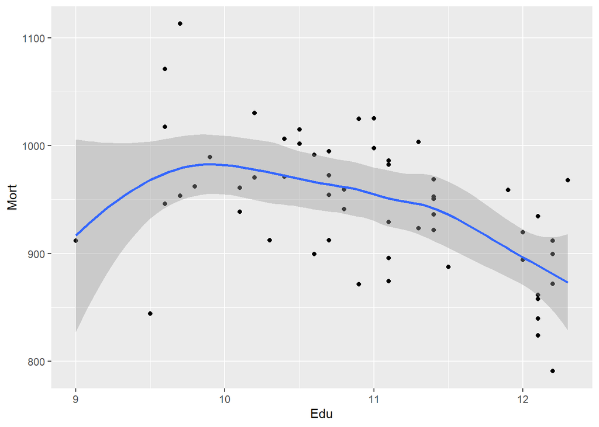

```r
ggplot(d,aes(x=Edu,y=Mort)) + geom_point() + geom_smooth()
```

- There are at least three outliers, but there is negative relation between them.

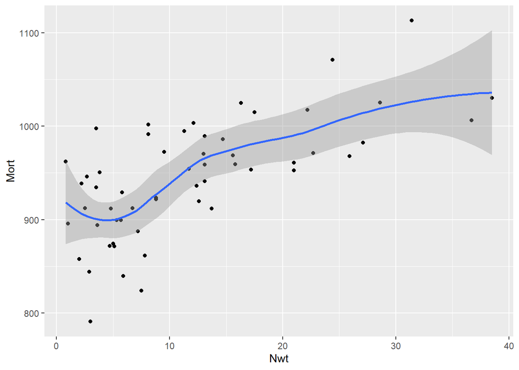

```r
ggplot(d,aes(x=Nwt,y=Mort)) + geom_point() + geom_smooth()
```

- There is positive correlation between Nwt and Mort.

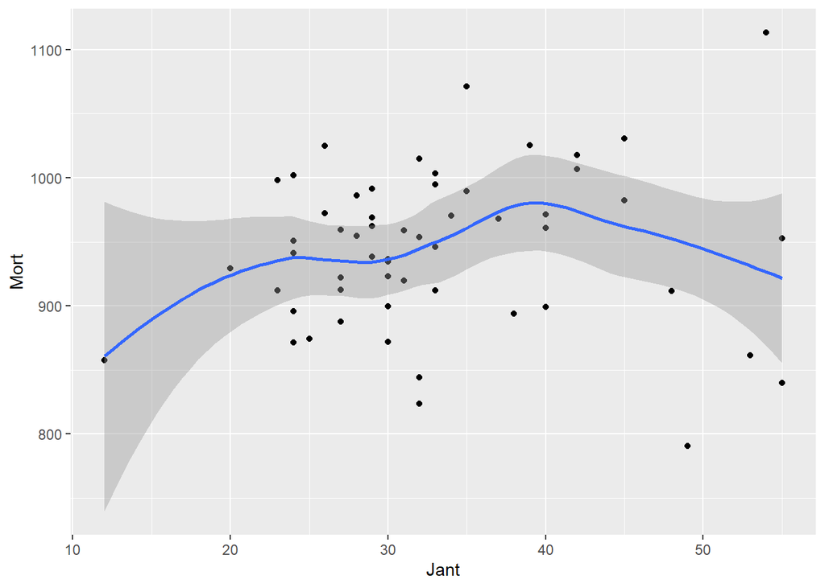

```r
ggplot(d,aes(x=Jant,y=Mort)) + geom_point() + geom_smooth()
```

- There is possible positive relation between them. There are at least 2 outlier city.

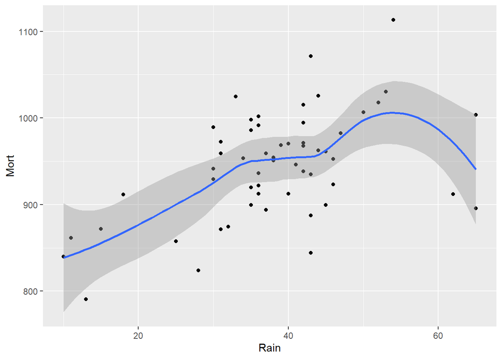

```r
ggplot(d,aes(x=Rain,y=Mort)) + geom_point() + geom_smooth()
```

- There is positive correlation between them.

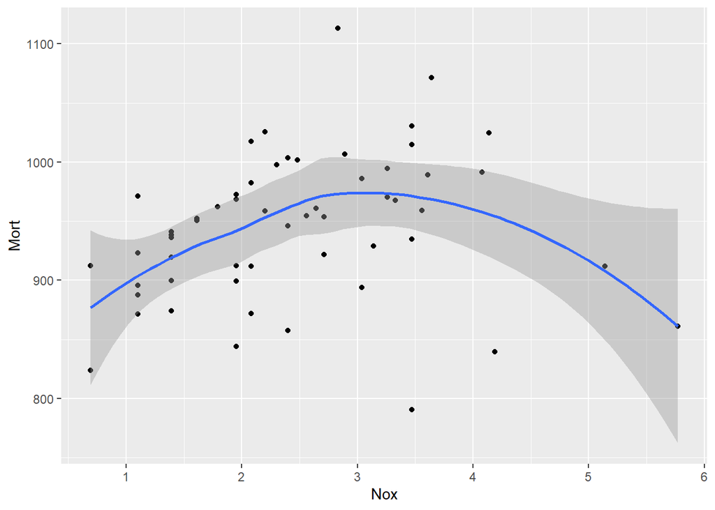

```r
ggplot(d,aes(x=Nox,y=Mort)) + geom_point() + geom_smooth()
```

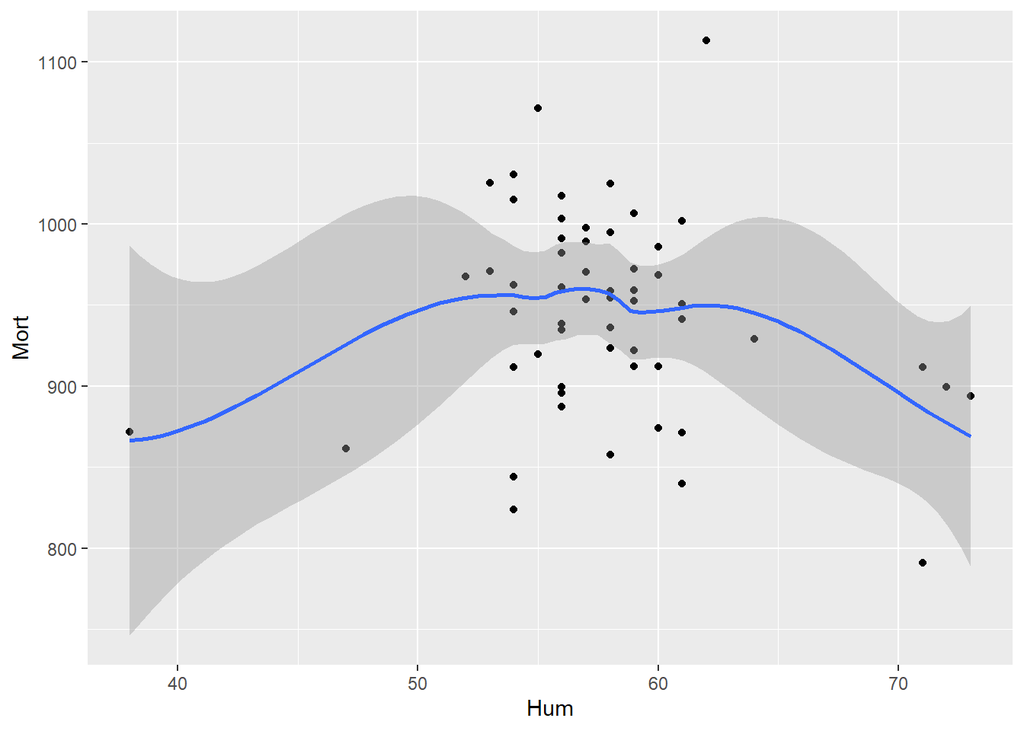

```r
ggplot(d,aes(x=Hum,y=Mort)) + geom_point() + geom_smooth()
```

- Interpret this Hum data with our response variable Mort is hard by just looking this graph. There are just 56 city in data so maybe adding new data may create possible relations. I try to deeply look by looking Cook’s distances.

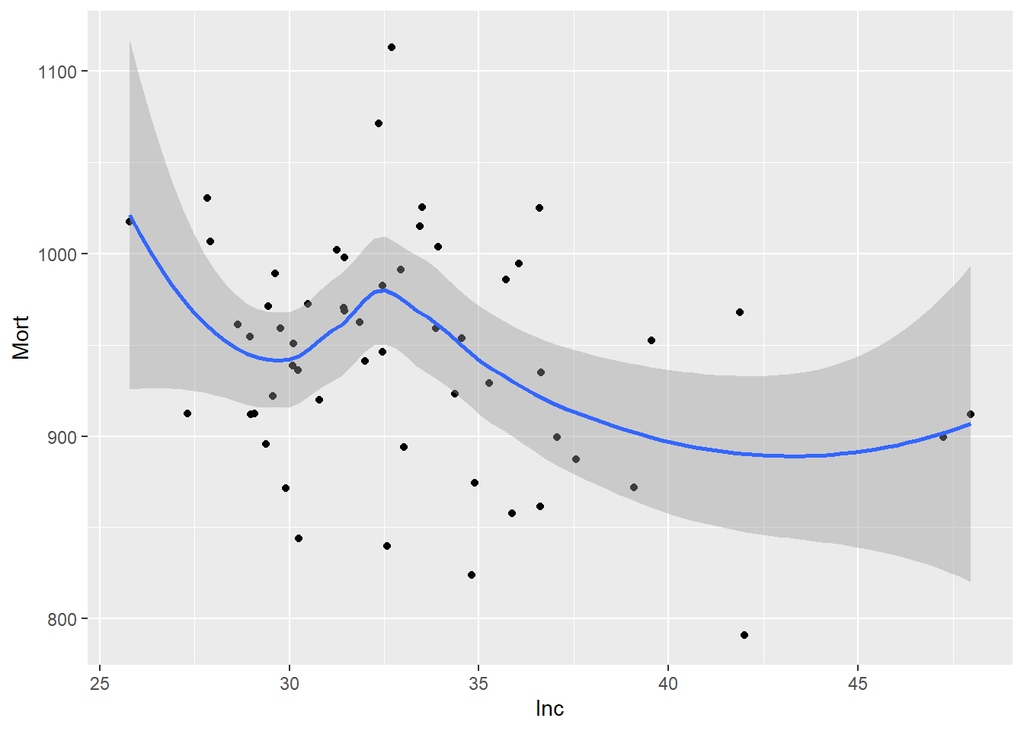

```r
ggplot(d,aes(x=Inc,y=Mort)) + geom_point() + geom_smooth()
```

- There might be negative correlation but there are lots of outliers.
- So lets create a multiple linear regression model, after that I will eliminate the some of the predictors to fit the best linear model.
- I did not want to add city data, it is just representing the where this data is taken from.

```r
d0 <- d %>%
  select(-City)
```

```r
first_model <- lm(Mort ~ ., data = d0)
summary(first_model)
```

```
Call:
lm(formula = Mort ~ ., data = d0)

Residuals:
    Min      1Q  Median      3Q     Max
-84.380 -22.118   2.907  23.154  77.369

Coefficients:
             Estimate Std. Error t value Pr(>|t|)
(Intercept) 1006.2441    95.0827  10.583 3.84e-14 ***
Edu          -15.3459     7.2515  -2.116  0.03954 *
Nwt            4.2140     0.6850   6.152 1.47e-07 ***
Jant          -2.1500     0.6593  -3.261  0.00204 **
Rain           1.6238     0.5643   2.878  0.00596 **
Nox           18.5481     5.5065   3.368  0.00150 **
Hum            0.5371     0.9024   0.595  0.55451
Inc           -0.3453     1.3038  -0.265  0.79227
---
Signif. codes:  0 '***' 0.001 '**' 0.01 '*' 0.05 '.' 0.1 ' ' 1

Residual standard error: 35.48 on 48 degrees of freedom
Multiple R-squared:  0.7137,    Adjusted R-squared:  0.6719
F-statistic: 17.09 on 7 and 48 DF,  p-value: 4.183e-11
```

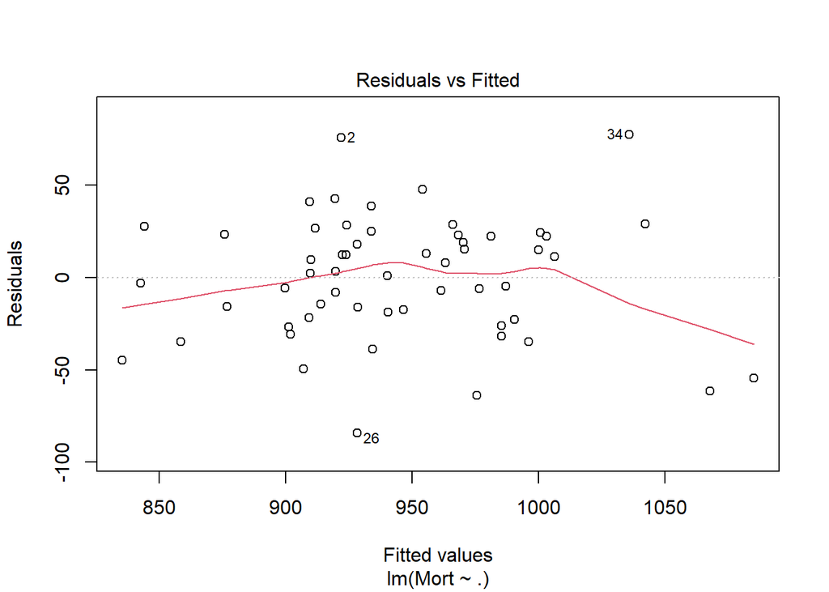

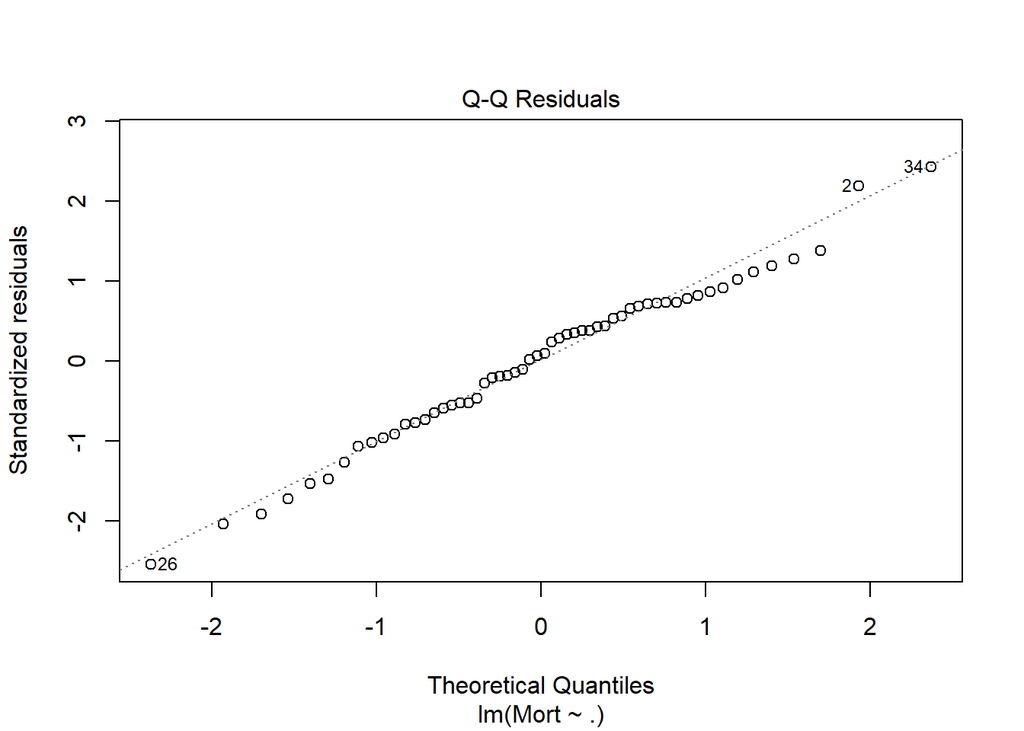

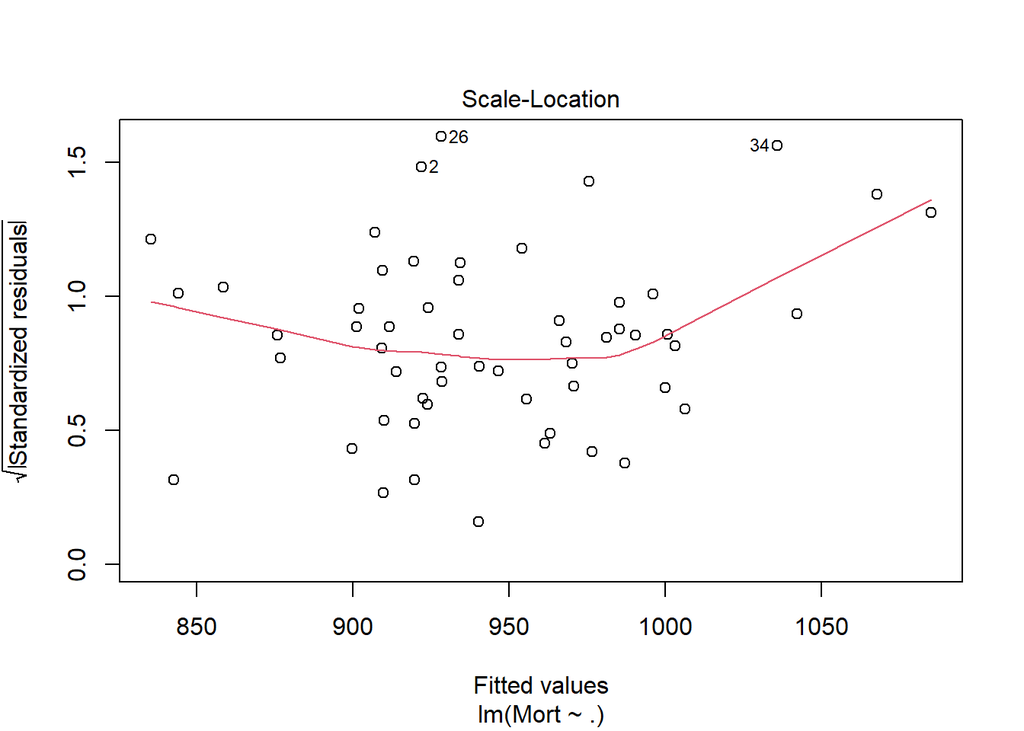

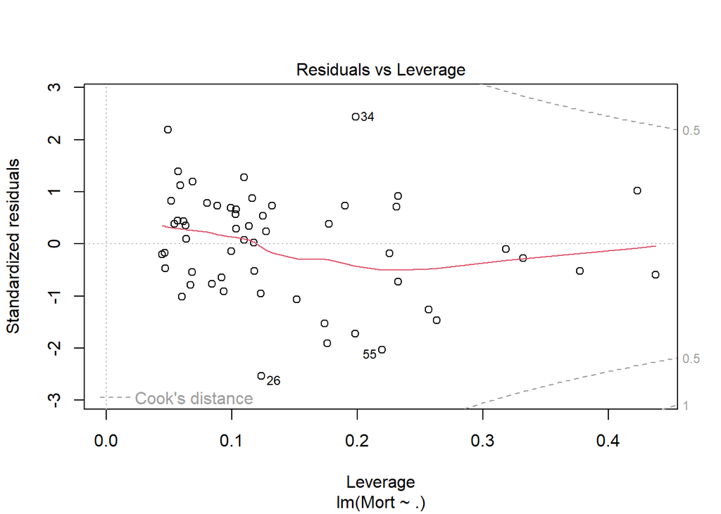

```r
plot(first_model)
```

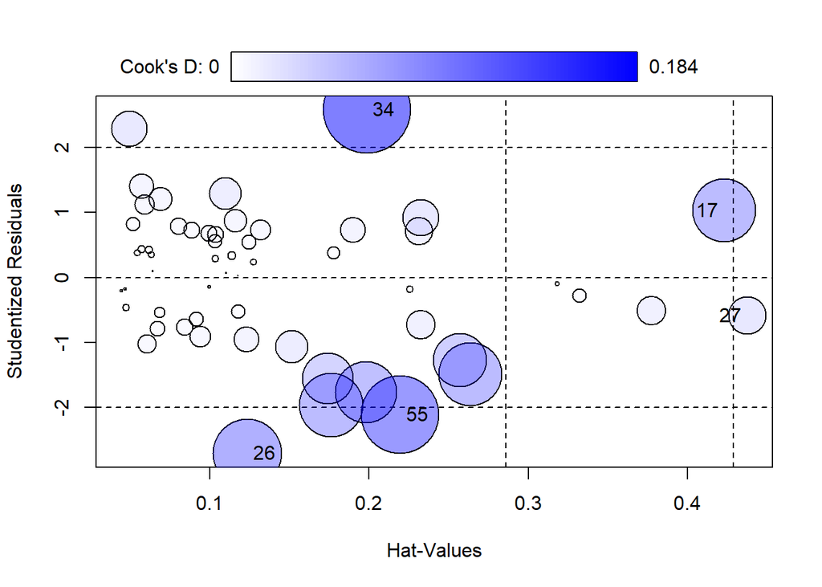

```
      StudRes       Hat      CookD
17  1.0243711 0.4228879 0.09601601
26 -2.7020870 0.1235403 0.11371471
27 -0.5859623 0.4375423 0.03385023
34  2.5750438 0.1986490 0.18389483
55 -2.1085833 0.2194692 0.14580207
```

```r
influencePlot(first_model)
```

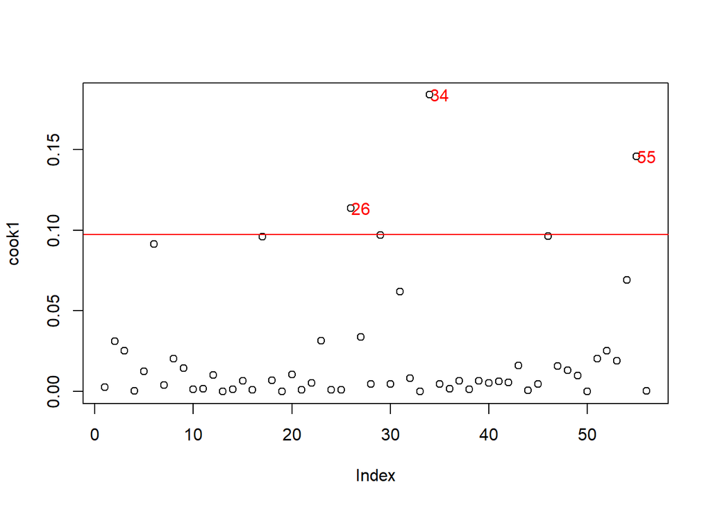

```r
cook1 <- cooks.distance(first_model)
plot(cook1)
abline(h = 4*mean(cook1, na.rm=T), col="red")
text(x=1:length(cook1)+1, y=cook1, labels=ifelse(cook1>4*mean(cook1, na.rm=T),names(cook1),""), col="red")
```

```r
outliers0 <- as.numeric(names(cook1)[(cook1 > 4*mean(cook1, na.rm=T))])  # outlier row numbers
head(d0[outliers0, ])  # outlier observations.
```

```
# A tibble: 3 × 8
   Mort   Edu   Nwt  Jant  Rain   Nox   Hum   Inc
  <dbl> <dbl> <dbl> <dbl> <dbl> <dbl> <dbl> <dbl>
1  844.   9.5   2.9    32    43  1.95    54  30.2
2 1113.   9.7  31.4    54    54  2.83    62  32.7
3  912.   9     4.8    33    62  2.08    54  29.0
```

```r
d1 <- d0 %>% slice(-c(26, 34, 55))
d1
```

```
# A tibble: 53 × 8
    Mort   Edu   Nwt  Jant  Rain   Nox   Hum   Inc
   <dbl> <dbl> <dbl> <dbl> <dbl> <dbl> <dbl> <dbl>
 1  922.  11.4   8.8    27    36  2.71    59  29.6
 2  998.  11     3.5    23    35  2.3     57  31.5
 3  962.   9.8   0.8    29    44  1.79    54  31.9
 4  982.  11.1  27.1    45    47  2.08    56  32.5
 5 1071.   9.6  24.4    35    43  3.64    55  32.4
 6 1030.  10.2  38.5    45    53  3.47    54  27.8
 7  935.  12.1   3.5    30    43  3.47    56  36.6
 8  900.  10.6   5.3    30    45  1.39    56  47.3
 9 1002.  10.5   8.1    24    36  2.48    61  31.2
10  912.  10.7   6.7    27    36  1.95    59  29.1
# ℹ 43 more rows
```

```r
second_model <- lm(Mort ~ ., data = d1)
summary(second_model)
```

```
Call:
lm(formula = Mort ~ ., data = d1)

Residuals:
    Min      1Q  Median      3Q     Max
-57.483 -22.919   5.845  19.452  66.537

Coefficients:
             Estimate Std. Error t value Pr(>|t|)
(Intercept) 1107.4933    82.1237  13.486  < 2e-16 ***
Edu          -20.7553     6.4445  -3.221 0.002377 **
Nwt            3.0983     0.6178   5.015 8.75e-06 ***
Jant          -1.9900     0.5748  -3.462 0.001186 **
Rain           1.8868     0.4857   3.885 0.000333 ***
Nox           20.1554     4.5904   4.391 6.77e-05 ***
Hum           -0.1566     0.7606  -0.206 0.837861
Inc           -0.5213     1.0821  -0.482 0.632334
---
Signif. codes:  0 '***' 0.001 '**' 0.01 '*' 0.05 '.' 0.1 ' ' 1

Residual standard error: 29.36 on 45 degrees of freedom
Multiple R-squared:  0.7737,    Adjusted R-squared:  0.7385
F-statistic: 21.98 on 7 and 45 DF,  p-value: 1.428e-12
```

- Hum and Inc seem to be not significant to the model. Let’s put them out.

```r
third_model <- lm(Mort ~ . - Hum - Inc, data = d1)
summary(third_model)
```

```
Call:
lm(formula = Mort ~ . - Hum - Inc, data = d1)

Residuals:
    Min      1Q  Median      3Q     Max
-55.417 -21.523   4.983  19.348  67.621

Coefficients:
             Estimate Std. Error t value Pr(>|t|)
(Intercept) 1098.1850    72.7434  15.097  < 2e-16 ***
Edu          -22.1203     5.7692  -3.834 0.000374 ***
Nwt            3.1615     0.5901   5.358 2.48e-06 ***
Jant          -2.0361     0.5569  -3.656 0.000645 ***
Rain           1.8858     0.4763   3.959 0.000253 ***
Nox           19.6295     4.3946   4.467 4.97e-05 ***
---
Signif. codes:  0 '***' 0.001 '**' 0.01 '*' 0.05 '.' 0.1 ' ' 1

Residual standard error: 28.81 on 47 degrees of freedom
Multiple R-squared:  0.7723,    Adjusted R-squared:  0.7481
F-statistic: 31.89 on 5 and 47 DF,  p-value: 5.044e-14
```

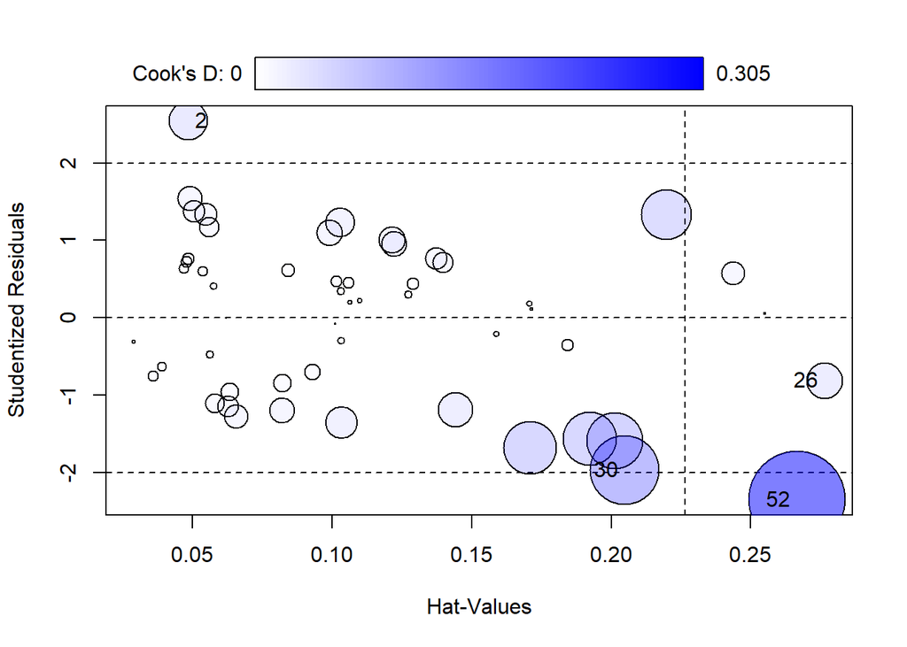

```
      StudRes        Hat      CookD
2   2.5420449 0.04856166 0.04924715
26 -0.8140536 0.27648905 0.04251241
30 -1.9666430 0.20478129 0.15645238
52 -2.3514657 0.26649959 0.30539723
```

```r
influencePlot(third_model)
```

- There are still some outliers but our number of data is not much so I don’t want to slice them it may cause to overfit. So let’s moving.

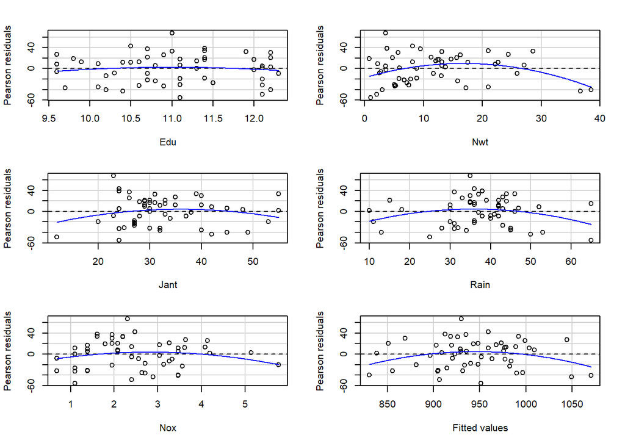

```
           Test stat Pr(>|Test stat|)
Edu          -0.6781          0.50108
Nwt          -2.5609          0.01379 *
Jant         -1.3283          0.19064
Rain         -2.3448          0.02341 *
Nox          -1.2755          0.20852
Tukey test   -2.1899          0.02853 *
---
Signif. codes:  0 '***' 0.001 '**' 0.01 '*' 0.05 '.' 0.1 ' ' 1
```

```r
residualPlots(third_model)
```

- Tukey test and last figure suggest that the model has room for improvement.
- Let’s check if the data needs a transformation.

```r
res_pt <-
  powerTransform(cbind(Mort, Edu, Nwt, Jant, Rain, Nox) ~
                   1,
                 d1)
summary(res_pt)
```

```
bcPower Transformations to Multinormality
     Est Power Rounded Pwr Wald Lwr Bnd Wald Upr Bnd
Mort    2.0978         1.0      -0.5747       4.7704
Edu     2.6642         1.0      -1.1334       6.4618
Nwt     0.4245         0.5       0.1687       0.6804
Jant    0.5184         1.0      -0.1157       1.1525
Rain    0.6796         1.0       0.1772       1.1819
Nox     0.4501         0.0      -0.0367       0.9368

Likelihood ratio test that transformation parameters are equal to 0
 (all log transformations)
                                     LRT df       pval
LR test, lambda = (0 0 0 0 0 0) 28.03202  6 9.2667e-05

Likelihood ratio test that no transformations are needed
                                     LRT df       pval
LR test, lambda = (1 1 1 1 1 1) 28.33261  6 8.1333e-05
```

- We reject the null hypothesis that the data does not need any transformation.

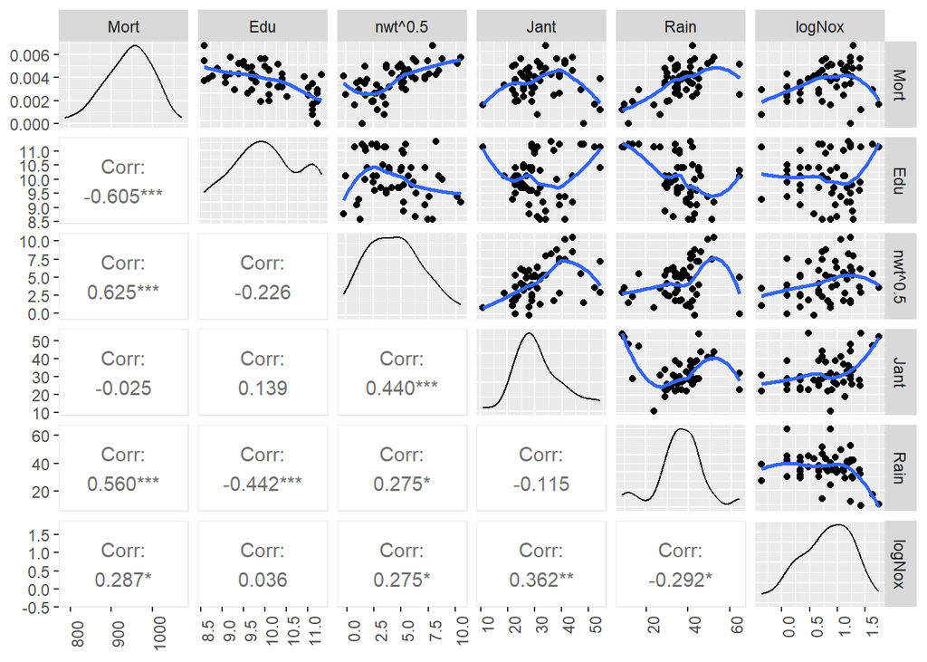

```r
mort_transform <- bcPower(dplyr::select(d1,Mort,Edu,Nwt,Jant,Rain,Nox), lambda=coef(res_pt,round = TRUE))%>%
  set_names(c("Mort","Edu","nwt^0.5","Jant","Rain","logNox"))


mort_transform %>%
  relocate(Mort) %>%
  ggpairs(progress = FALSE,
          upper = list(continuous = my_fn),
          lower = list(continuous = "cor"))+theme(axis.text.x = element_text(angle = 90))
```

# 2

```r
fourth_model <-
  lm(
    Mort ~ Edu + I(Nwt^0.5) + Jant + Rain + log(Nox),
    d1
  )
summary(fourth_model)
```

```
Call:
lm(formula = Mort ~ Edu + I(Nwt^0.5) + Jant + Rain + log(Nox),
    data = d1)

Residuals:
    Min      1Q  Median      3Q     Max
-43.862 -24.347   3.277  16.499  67.137

Coefficients:
             Estimate Std. Error t value Pr(>|t|)
(Intercept) 1069.8917    66.7655  16.025  < 2e-16 ***
Edu          -22.0419     5.2936  -4.164 0.000133 ***
I(Nwt^0.5)    21.5387     3.6454   5.909 3.70e-07 ***
Jant          -1.8306     0.4921  -3.720 0.000530 ***
Rain           1.9287     0.4131   4.669 2.56e-05 ***
log(Nox)      45.1515     8.8471   5.104 5.92e-06 ***
---
Signif. codes:  0 '***' 0.001 '**' 0.01 '*' 0.05 '.' 0.1 ' ' 1

Residual standard error: 26.52 on 47 degrees of freedom
Multiple R-squared:  0.8071,    Adjusted R-squared:  0.7865
F-statistic: 39.32 on 5 and 47 DF,  p-value: 1.099e-15
```

- At our first model we have RSE: 35.48, Multiple R-squared: 0.7137, Adjusted R-squared: 0.6719
- Now we have less RSE, and also Multiple R-squared: 0.8071, Adjusted R-squared: 0.7865. We improved our model.

# 3

- The Adjusted R2 value is 0.7865 So this proportion of the variance can be explained by this model.
- Let’s also check the diagnostic plots.

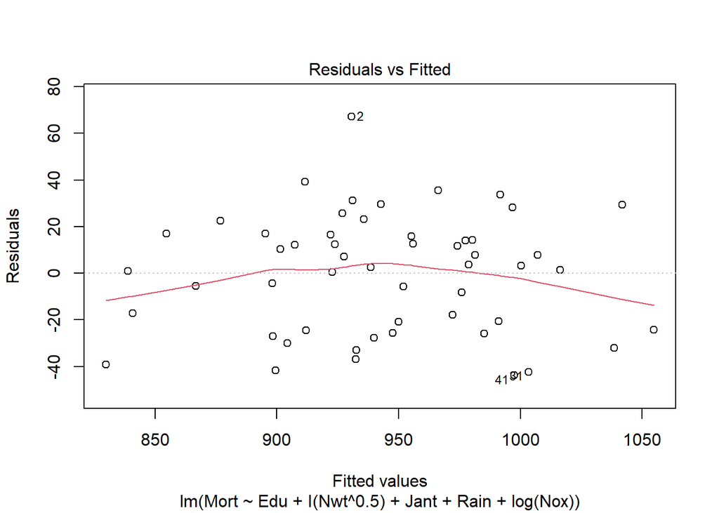

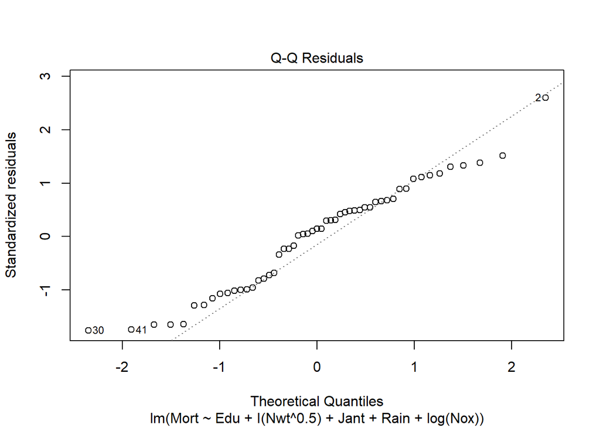

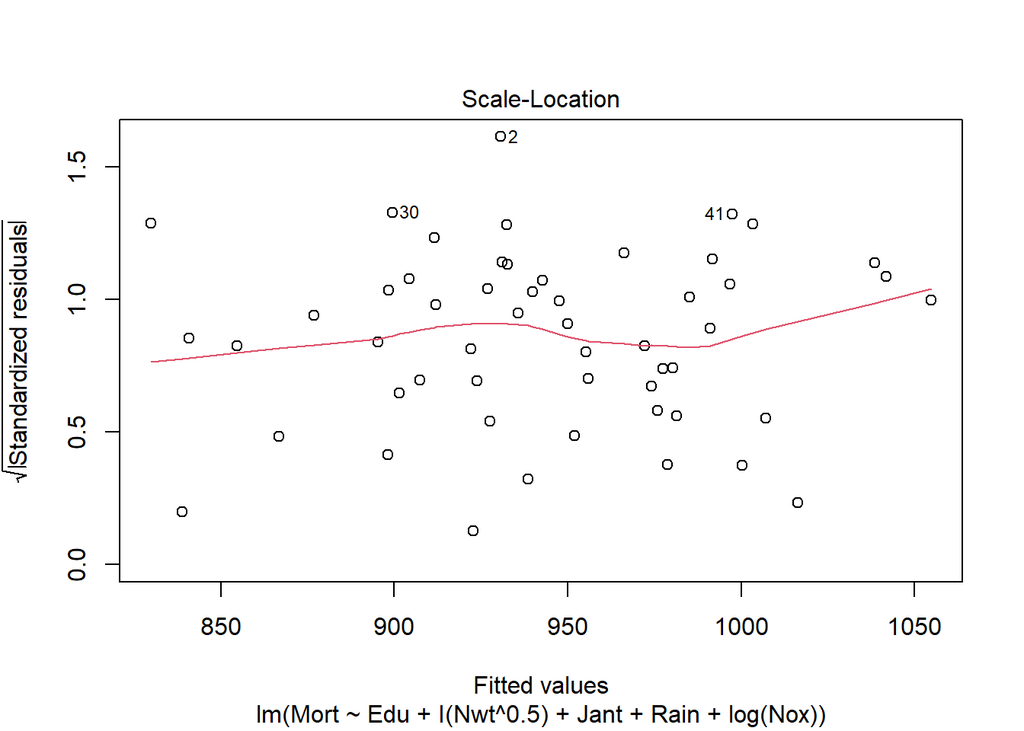

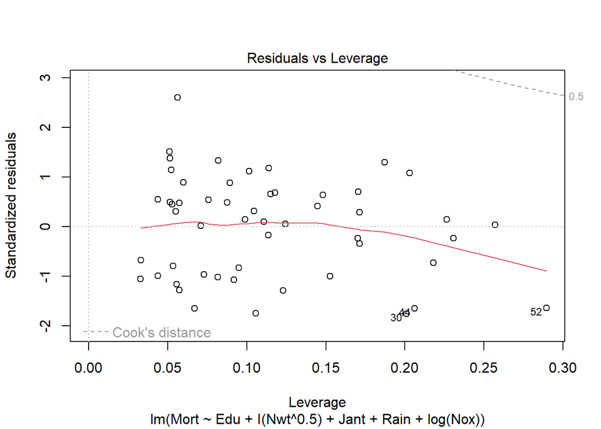

```r
plot(fourth_model)
```

- Fitted vs Residuals plot has a better shape than the previous model. The red curve is around 0. But still somehow has a downside U kind of shape.
- Normality seems not to be satisfied. There are lots of points which are not on the QQ plot.
- The number of points who have high variances is low than previous models so no drastic changes in variance.
- Cook’s Distance values are less than 0.5. Hence there are no influential points based on this criteria.
- Let’s check Fitted vs. Studentized Resiudals and Leverage vs. Studentized Residuals plots.

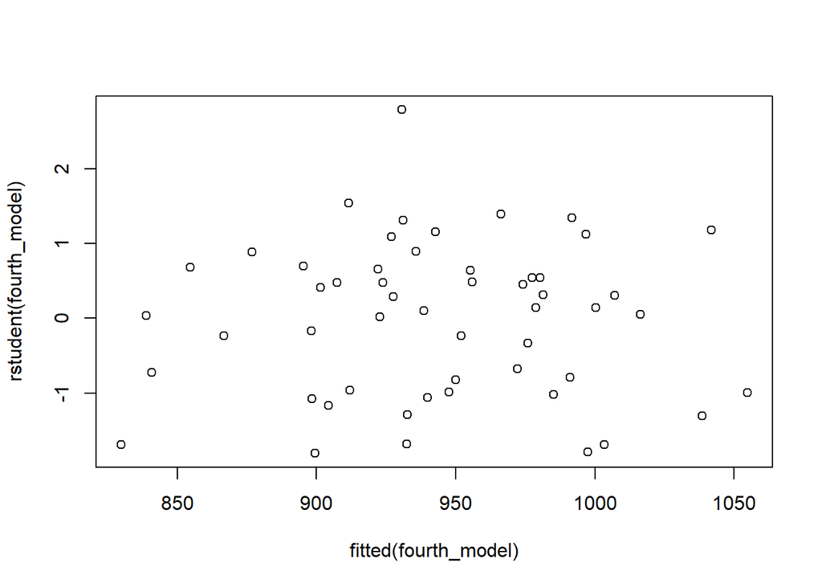

```r
plot(fitted(fourth_model), rstudent(fourth_model))
abline(h = c(-3, 3), lty = "dotted")
```

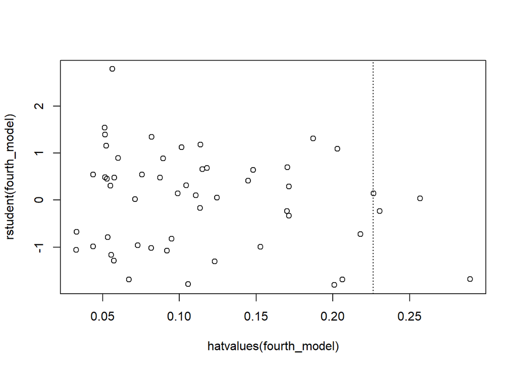

```r
plot(hatvalues(fourth_model), rstudent(fourth_model))
abline(v = c(2, 3) * (1 - df.residual(fourth_model) / nobs(fourth_model)), lty = "dotted")
```

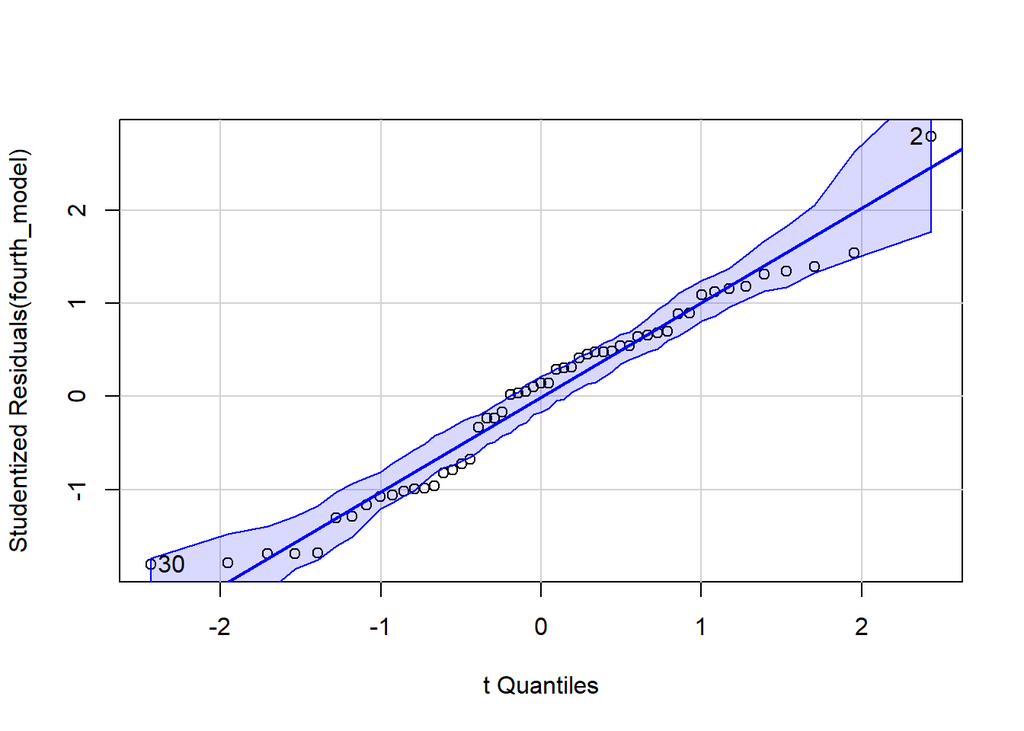

```
[1]  2 30
```

```r
qqPlot(fourth_model)
```

```r
shapiro.test(rstudent(fourth_model))
```

```
    Shapiro-Wilk normality test

data:  rstudent(fourth_model)
W = 0.96653, p-value = 0.1425
```

- We could not reject that residuals are normally distributed.

```r
ncvTest(fourth_model)
```

```
Non-constant Variance Score Test
Variance formula: ~ fitted.values
Chisquare = 0.0120865, Df = 1, p = 0.91246
```

- We also could not reject that the variance is constant for this model.
- Slicing the outlier data and having less data can cause of it.

# 4

```r
anova(fourth_model)
```

```
Analysis of Variance Table

Response: Mort
           Df Sum Sq Mean Sq F value    Pr(>F)
Edu         1  62634   62634 89.0257 2.020e-12 ***
I(Nwt^0.5)  1  43104   43104 61.2658 4.618e-10 ***
Jant        1   7780    7780 11.0580  0.001719 **
Rain        1   6471    6471  9.1976  0.003937 **
log(Nox)    1  18325   18325 26.0462 5.922e-06 ***
Residuals  47  33067     704
---
Signif. codes:  0 '***' 0.001 '**' 0.01 '*' 0.05 '.' 0.1 ' ' 1
```

-Based on the p-values, the significant main effects are as follows: -Edu (Education), I(Nwt^0.5), Jant, Rain, log(Nox) -These factors are statistically significant and have a meaningful impact on the response variable Mort (presumably mortality rates).

# 5

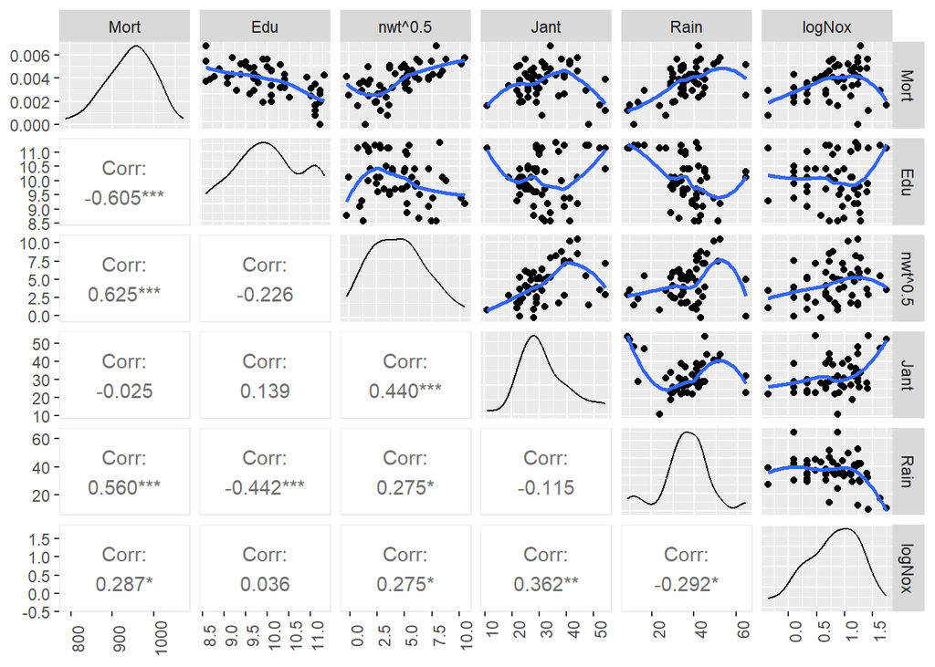

```r
mort_transform %>%
  relocate(Mort) %>%
  ggpairs(progress = FALSE,
          upper = list(continuous = my_fn),
          lower = list(continuous = "cor"))+theme(axis.text.x = element_text(angle = 90))
```

- Edu-Rain, Jant-Nwt^0.5 might be interacting predictors. I try to discrete data and deeply looked to interaction plots.

```r
ndisc <- 4
d1_int <- d1 %>%
  map(~{seq(min(.x), max(.x), len = ndisc)}) # discretization intervals

d1_findInt <- map2(d1, d1_int, ~{
  findInterval(x = .x, vec = .y, )
}) # finds the discretization intervals into which each obs falls.

d1_disc <- map2(d1_findInt, d1_int, ~{
  .y[.x]
})

discretize <- function(x, breaks = 3){
  ## dissect the numerical vector <x> into <breaks> intervals and replace each value
  ## with the mid-point of the assigned interval. Alternatively breaks can be a
  ## numerical vector of break points.
  xx <- cut(x, breaks = unique(breaks), include.lowest = TRUE)
  xxlevels <- levels(xx)
  lreg <- gregexpr("(?<=[\\(\\[]).*(?=,)", xxlevels, perl = TRUE)
  lb <- regmatches(xxlevels, lreg) %>% unlist() %>% as.numeric()
  ureg <- gregexpr("(?<=,).*(?=\\])", xxlevels, perl = TRUE)
  ub <- regmatches(xxlevels, ureg) %>% unlist() %>% as.numeric()
  mid <- (lb + ub)/2
  mid[as.numeric(xx)]
}

d1_disc <- map(d1, discretize, breaks = ndisc)
map(d1_disc, table)
```

```
$Mort

825.5   896 965.5  1035
    4    16    24     9

$Edu

 9.95  10.6 11.25 11.95
   10    15    15    13

$Nwt

5.481 14.95  24.4  33.8
   27    16     8     2

$Jant

 17.4 28.15 38.85  49.6
    2    33    11     7

$Rain

16.875  30.65  44.35  58.15
     5     22     22      4

$Nox

1.3225  2.595  3.865   5.14
    20     18     13      2

$Hum

 42.4 51.15 59.85  68.6
    1    11    37     4

$Inc

28.55  34.1 39.65  45.2
   19    26     6     2
```

```r
# d0 %>% head()
# d0_disc %>% head()
```

```r
d1_disc_df <- d1_disc %>%
  as_tibble %>%
  mutate(Mort = d1$Mort)%>%
  group_by_at(vars(-Mort)) %>%
  summarize(Mort = mean(Mort), .groups = "drop")
```

```r
d1_disc_df %>%
  group_by(Edu, Rain) %>%
  summarize(Mort = mean(Mort)) %>%
  pivot_wider(names_from = Rain, values_from = Mort)
```

[output not shown]

```
# A tibble: 4 × 5
# Groups:   Edu [4]
    Edu `30.65` `44.35` `58.15` `16.875`
  <dbl>   <dbl>   <dbl>   <dbl>    <dbl>
1  9.95    971.    975.   1024.      NA
2 10.6     969.    965.     NA       NA
3 11.2     941.    956.    950.      NA
4 12.0     892.    951.     NA      855.
```

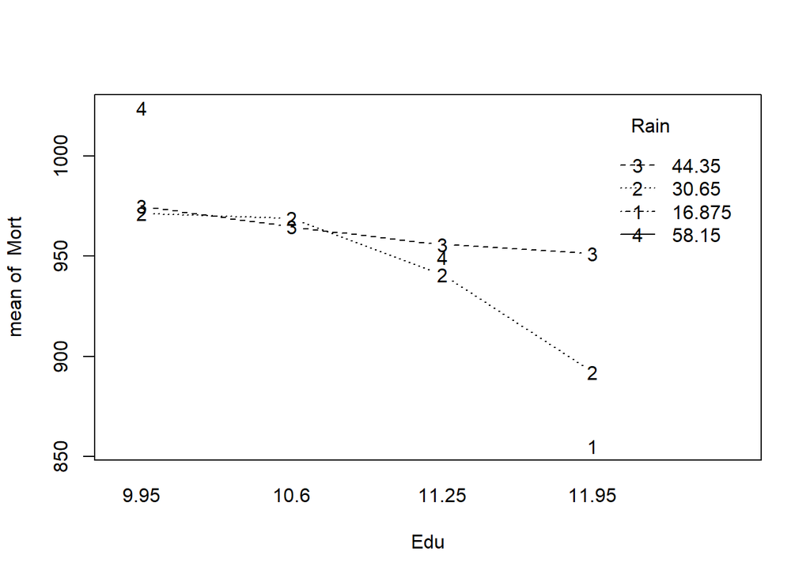

```r
with(d1_disc_df,
     interaction.plot(x.factor = Edu, trace.factor = Rain, response = Mort, type = "b")
)
```

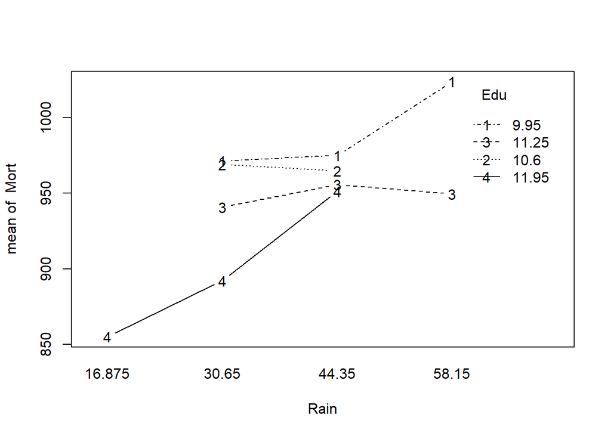

```r
with(d1_disc_df,
     interaction.plot(x.factor = Rain, trace.factor = Edu, response = Mort, type = "b")
)
```

- I couldnot find any interaction, lets try to find other interactions.

```r
d1_disc_df %>%
  group_by(Nwt, Jant) %>%
  summarize(Mort = mean(Mort)) %>%
  pivot_wider(names_from = Jant, values_from = Mort)
```

[output not shown]

```
# A tibble: 4 × 5
# Groups:   Nwt [4]
    Nwt `17.4` `28.15` `38.85` `49.6`
  <dbl>  <dbl>   <dbl>   <dbl>  <dbl>
1  5.48   893.    925.    897.   831.
2 15.0     NA     969.    980.   912.
3 24.4     NA      NA    1002.   967.
4 33.8     NA      NA    1006.  1030.
```

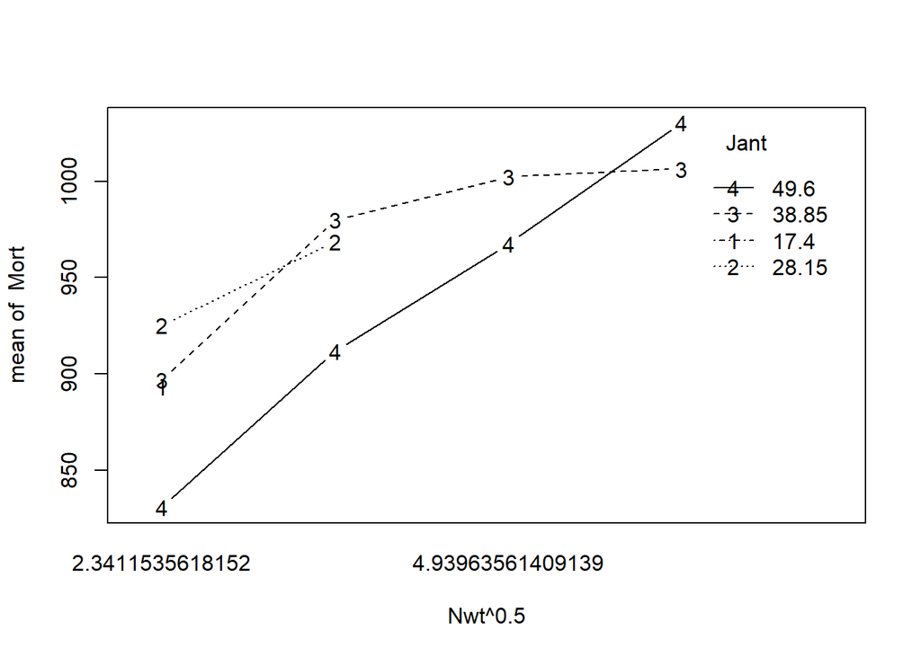

```r
with(d1_disc_df,
     interaction.plot(x.factor = Nwt^0.5, trace.factor = Jant, response = Mort, type = "b")
)
```

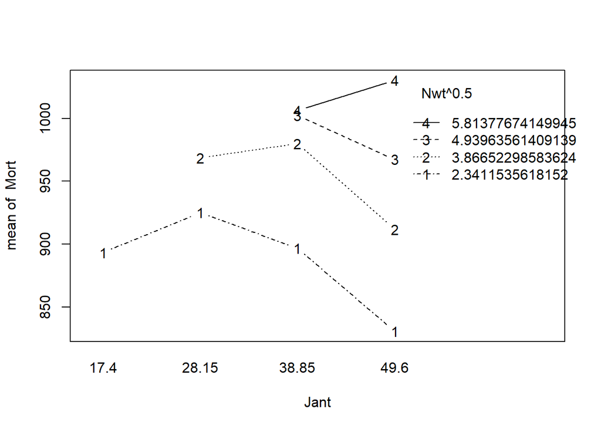

```r
with(d1_disc_df,
     interaction.plot(x.factor = Jant, trace.factor = Nwt^0.5, response = Mort, type = "b")
)
```

- It is hard to tell there is an interaction between them so lets create a model and looked it.

```r
res1 <- update(fourth_model, . ~ . + Jant:I(Nwt^0.5))
summary(res1)
```

```
Call:
lm(formula = Mort ~ Edu + I(Nwt^0.5) + Jant + Rain + log(Nox) +
    I(Nwt^0.5):Jant, data = d1)

Residuals:
    Min      1Q  Median      3Q     Max
-44.767 -21.266   1.579  16.773  68.897

Coefficients:
                 Estimate Std. Error t value Pr(>|t|)
(Intercept)     1050.9262    80.6880  13.025  < 2e-16 ***
Edu              -22.0014     5.3411  -4.119 0.000157 ***
I(Nwt^0.5)        27.2063    13.7768   1.975 0.054313 .
Jant              -1.3309     1.2716  -1.047 0.300731
Rain               1.9892     0.4402   4.518 4.34e-05 ***
log(Nox)          44.5670     9.0295   4.936 1.09e-05 ***
I(Nwt^0.5):Jant   -0.1620     0.3794  -0.427 0.671467
---
Signif. codes:  0 '***' 0.001 '**' 0.01 '*' 0.05 '.' 0.1 ' ' 1

Residual standard error: 26.76 on 46 degrees of freedom
Multiple R-squared:  0.8078,    Adjusted R-squared:  0.7827
F-statistic: 32.23 on 6 and 46 DF,  p-value: 6.696e-15
```

- I think there is no interaction between them. Let’s try the other relation.

```r
res2 <- update(fourth_model, . ~ . + Edu:Rain)
summary(res2)
```

```
Call:
lm(formula = Mort ~ Edu + I(Nwt^0.5) + Jant + Rain + log(Nox) +
    Edu:Rain, data = d1)

Residuals:
    Min      1Q  Median      3Q     Max
-50.478 -21.697   2.014  16.023  66.062

Coefficients:
             Estimate Std. Error t value Pr(>|t|)
(Intercept) 1378.3313   259.9406   5.302 3.16e-06 ***
Edu          -49.6743    23.1222  -2.148   0.0370 *
I(Nwt^0.5)    20.3749     3.7479   5.436 2.01e-06 ***
Jant          -1.4264     0.5899  -2.418   0.0196 *
Rain          -6.2575     6.6827  -0.936   0.3540
log(Nox)      45.1993     8.7999   5.136 5.56e-06 ***
Edu:Rain       0.7168     0.5840   1.227   0.2260
---
Signif. codes:  0 '***' 0.001 '**' 0.01 '*' 0.05 '.' 0.1 ' ' 1

Residual standard error: 26.38 on 46 degrees of freedom
Multiple R-squared:  0.8132,    Adjusted R-squared:  0.7888
F-statistic: 33.37 on 6 and 46 DF,  p-value: 3.539e-15
```

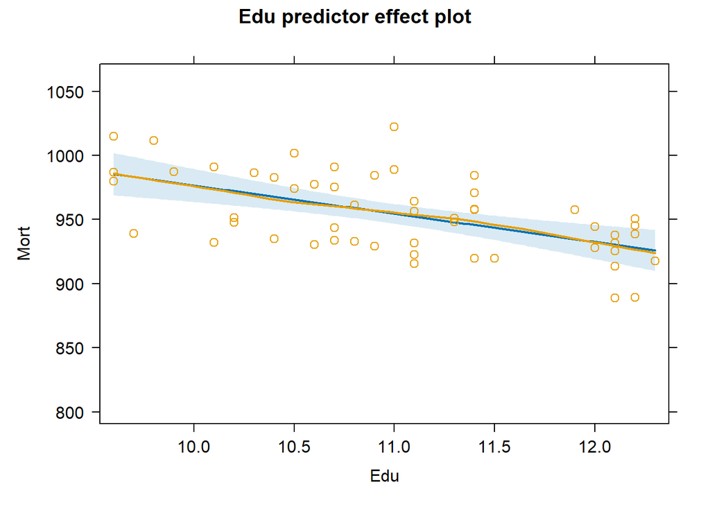

```r
predictorEffect("Edu", fourth_model, resid = TRUE) %>% plot()
```

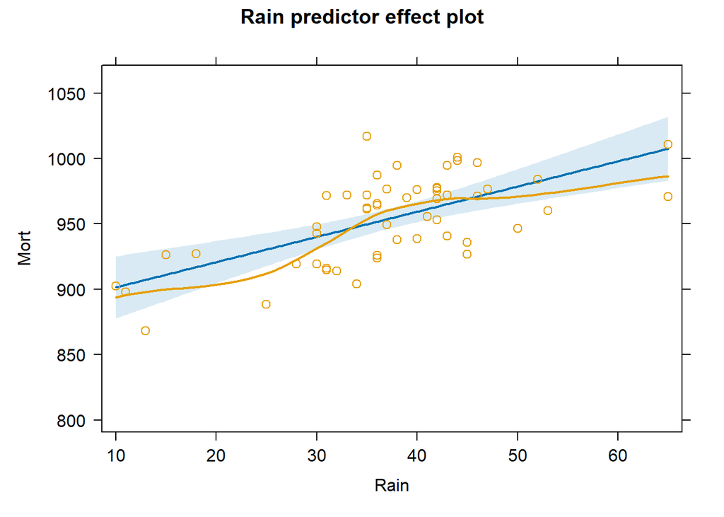

```r
predictorEffect("Rain", fourth_model, resid = TRUE) %>% plot()
```

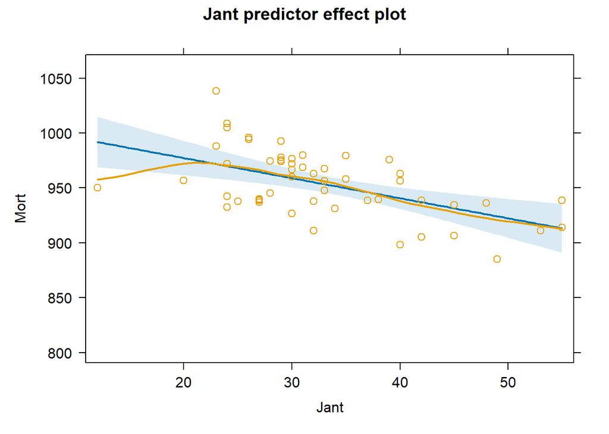

```r
predictorEffect("Jant", fourth_model, resid = TRUE) %>% plot()
```

# 6

```r
predict(
    fourth_model,
    newdata = data.frame(
       Edu = 10, Nwt = 15, Jant = 35, Rain = 40, Nox = 2
    ),
    interval = "confidence",
    level = 0.9
  )
```

```
       fit      lwr      upr
1 977.2645 966.1862 988.3428
```